# ETC3250/5250 Assignment 3

Jia Lin Gao (25982990), Yang Wang - leader (28463293),Alicia Lam (29676088), Tarushi Hondhe-Munige (28768361)

DUE: Friday, May 8 5pm

# Question 1

*About the data*: The chocolates data was compiled by students in a previous class of Prof Cook, by collecting nutrition information on the chocolates as listed on their internet sites. All numbers were normalised to be equivalent to a 100g serving. Units of measurement are listed in the variable name.

1. Use the tour, with type of chocolate mapped to colour, and write a paragraph on whether the two types of chocolate differ on the nutritional variables.

Uing a grand tour, we see that the dark and milk chocolates show a degree of differentiation on the most of the nutritional variables but to differing degrees, however some overlap remains on all variables. Fiber can be considered as the relatively significant variables among all the variables that disguish the two types.

2. Make a parallel coordinate plot of the chocolates, coloured by type, with the variables sorted by how well they separate the groups. Maybe the “uniminmax” scaling might work best for this data. Write a paragraph explaining how the types of chocolates differ in nutritional characteristics.

It does appear that the types of chocolates generally differ on many variables. The level of sodium and carbs including sugar, and cholestrol are higher in milk chocolates, higher sugar content may be due to the fact that milk chocolates tend to be sweetened to a higher degree, and the sodium could be due to the addition of milk, which is a feature unique to milk chocolates. Levels of fat and fiber are higher in dark chocolates, due to the increased volume of cocoa mass which has a high fiber content, and increased volume of cocoa butter, which is high in both saturated fat and total fat[1].

3. Identify one dark chocolate that is masquerading as dark, that is, nutritionally looks more like a milk chocolate. Explain your answer.

4. Fit a linear discriminant analysis model, using equal prior probability for each group.
5. Write down the LDA rule. Make it clear which type of chocolate is class 1 and class 2 relative to the formula in the notes.

The LDA model is

```
## Call:
## lda(Type ~ . - Name - MFR - Country, data = choc, prior = c(1/2,
##     1/2))
##
## Prior probabilities of groups:
## Milk Dark
##  0.5  0.5
##
## Group means:
##      Calories   CalFat TotFat_g SatFat_g   Chol_mg    Na_mg  Carbs_g  Fiber_g
## Milk 526.9849 273.8450 31.47193 18.32603 14.591722 76.45171 57.26107 2.342722
## Dark 550.8751 356.0898 39.98957 22.65993  4.476002 20.16651 45.73264 7.366818
##      Sugars_g Protein_g
## Milk 48.47795  6.704738
## Dark 31.09175  7.535377
##
## Coefficients of linear discriminants:
##                    LD1
## Calories   0.000450709
## CalFat    -0.001291990
## TotFat_g   0.064749708
## SatFat_g   0.007212263
## Chol_mg   -0.024273523
## Na_mg     -0.013936861
## Carbs_g    0.003824629
## Fiber_g    0.174212217
## Sugars_g  -0.015994165
## Protein_g -0.122232038
```

LDA models the predictors distribution seperately in each of the responses classes, which follow Bayes’ Theorm for classification. From which we find the LDA rule: Classes: Milk = 1, Dark = 2 Assign observation to class 1 if
$$x_0'\Sigma^{-1}(\mu_1-\mu_2)>\frac{1}{2}(\mu_1+\mu_2)'\Sigma^{-1}(\mu_1-\mu_2)\,|\,\pi_1=\pi_2\,where\,\Sigma\,is\,common\, for\, all\, k$$

# Question 2

This question is about decision trees. Here is a sample data set to work with:

```
##   id  x cl
## 1  1 -4  A
## 2  2 -2  A
## 3  3  1  A
## 4  4 11  B
## 5  5 15  B
## 6  6 16  A
## 7  7 19  B
## 8  8 20  B
```

1. Write down the formulae for the impurity metric, Gini, for a two group problem. Show that the Gini function has its highest value at 0.5. Explain why a value of 0.5 leads to the worst possible split.

$$G = \sum_{k =1}^K \hat{p}_{mk}(1 - \hat{p}_{mk})$$

where the {p}_{mk} is the proporation of training observations in the mth region that are from kth class.[2]

in a 2 group problem where $K = 2$

$$G = \hat{p}_{m1}(1-\hat{p}_{m1}) + \hat{p}_{m2}(1-\hat{p}_{m2})$$

$$\hat{p}_{m2} = 1-\hat{p}_{m1}$$
expand and simplify

$$G = 2\hat{p_{m1}}(1-\hat{p}_{m1})$$
when $\hat{p}_{m1} = \hat{p}_{m2} = 0.5$ G is maximised

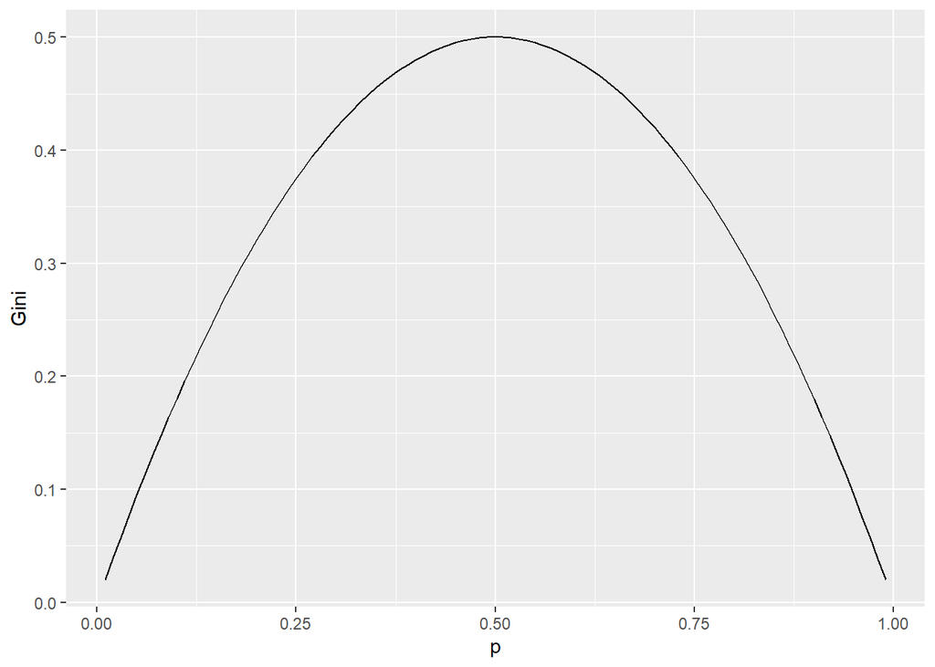

Intuitively this makes sense, when the Gini function is at 0.5, $\hat{p}_m$ is at 50%, which means that in the split region there is an even mix of classes and the classifier does not provide any additional information compared to random selection. When the groups are more “pure” than an even mix, the value of Gini will decrease.

2. Write an R function to compute the impurity measure. The input should be data frame containing a vector of numeric values, and a vector of the associated classes.
3. Use your function to compute the Gini impurity measure for every possible split of the sample data.
4. Make a plot of your splits and the impurity measure. What partition of the data would yield the best split?

The results show that the gini index is minimized where gini is at a minimum, note that a different sample is taken even when the seed is set, therefore the numerical values of the optimum split will be different each time.

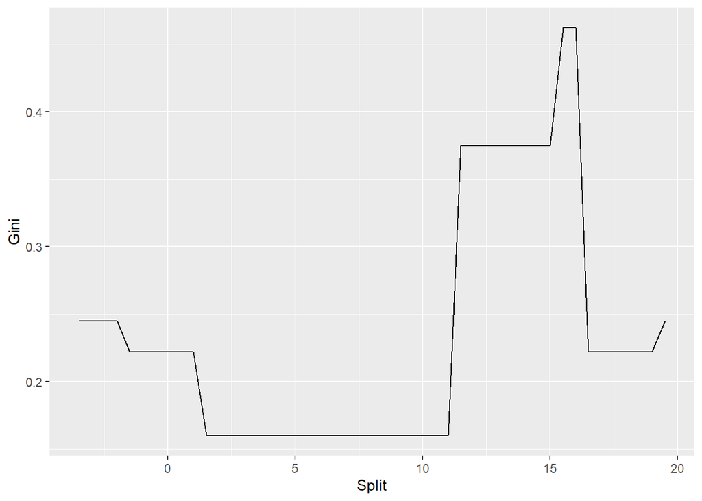

5. Fit a classification tree to the chocolates data. Print the tree model.

```
## n= 88
##
## node), split, n, loss, yval, (yprob)
##       * denotes terminal node
##
## 1) root 88 32 Dark (0.36363636 0.63636364)
##   2) Fiber_g< 4.825581 40 11 Milk (0.72500000 0.27500000)
##     4) CalFat< 337.7193 31  2 Milk (0.93548387 0.06451613) *
##     5) CalFat>=337.7193 9  0 Dark (0.00000000 1.00000000) *
##   3) Fiber_g>=4.825581 48  3 Dark (0.06250000 0.93750000) *
```

6. Compute Gini impurity measure for all possible splits on the Fiber variable in the chocolates data. Plot this against the splits. Explain where the best split is.

The best split for this dataset would be slightly above 5, as while higher split values have a lower gini index but that is because the prior odds of dark exceeds milk, therefore the purity would be from a higher $p$ dark in *both* groups.

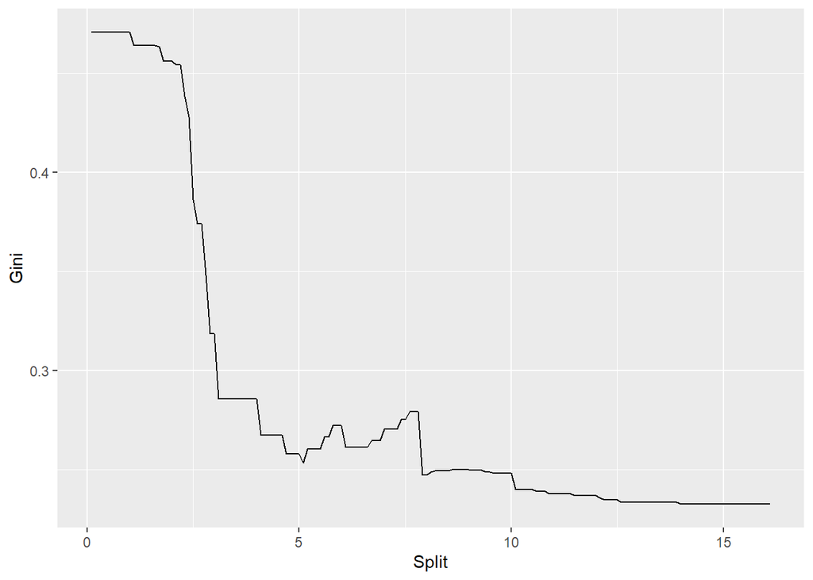

```
## # A tibble: 2 x 2
##   Type  `n()`
##   <fct> <int>
## 1 Milk     32
## 2 Dark     56
```

7. Compute Gini impurity measure for all possible splits on all of the other nutrition variables. Plot all of these values against the split, all 10 plots. Are there other possible candidates for splitting, that are almost as good as the one chosen by the tree? Explain yourself.

In addition to the variables chosen by the tree, sugar_g and Na_mg both have low value regions in the gini curve that are distinct which make them good candidates as splitting variables.

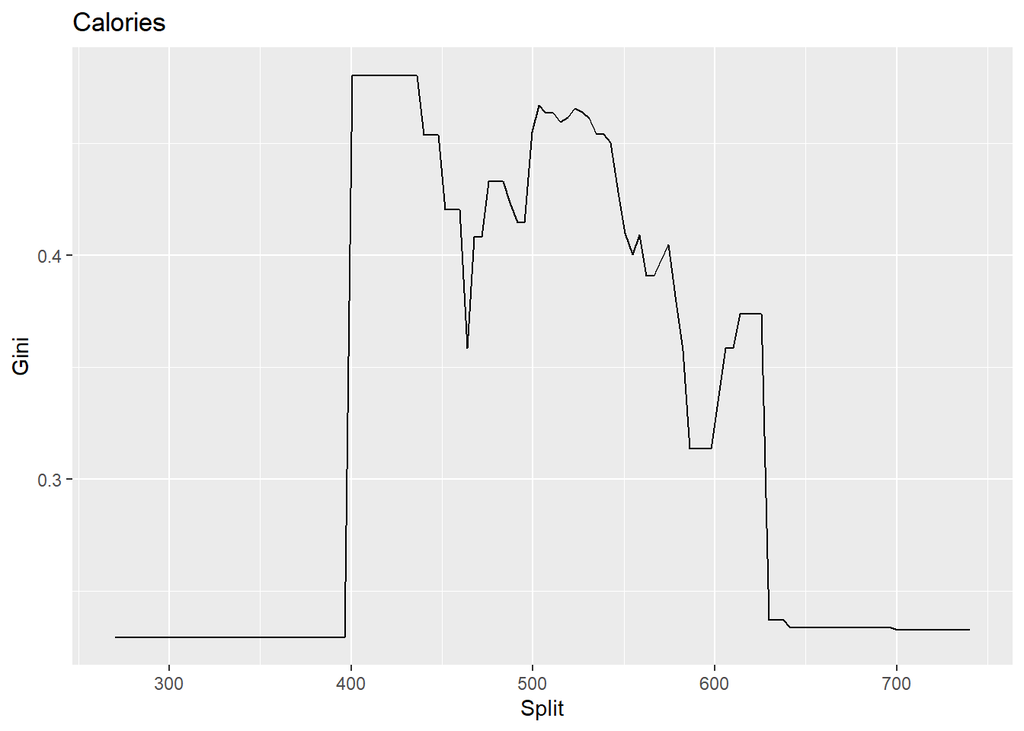

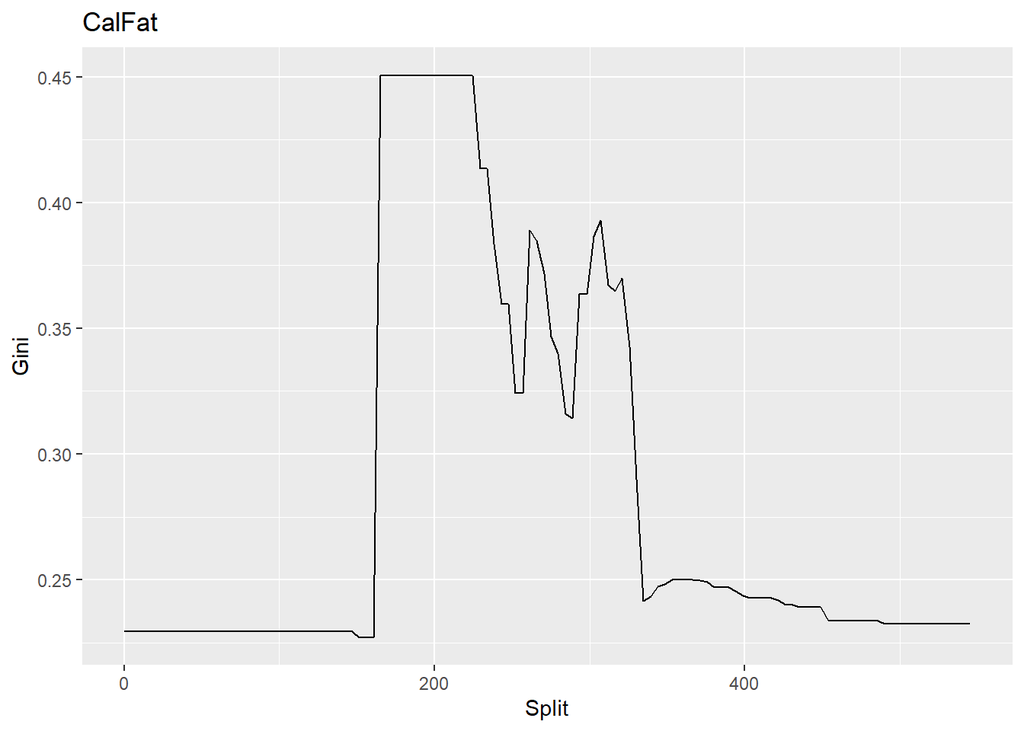

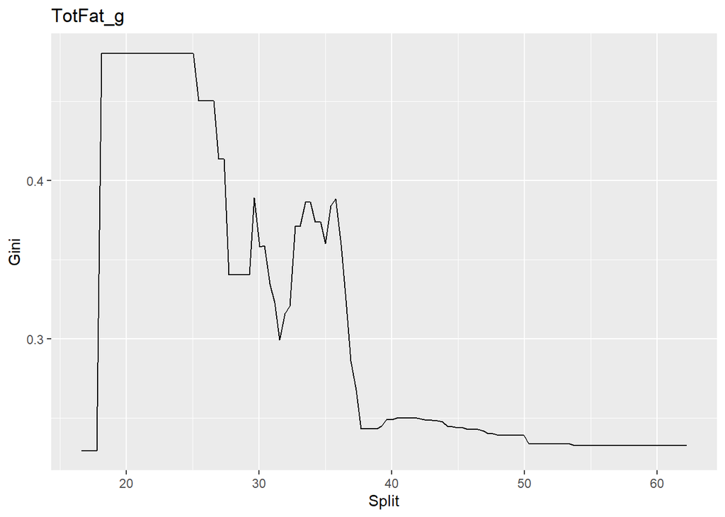

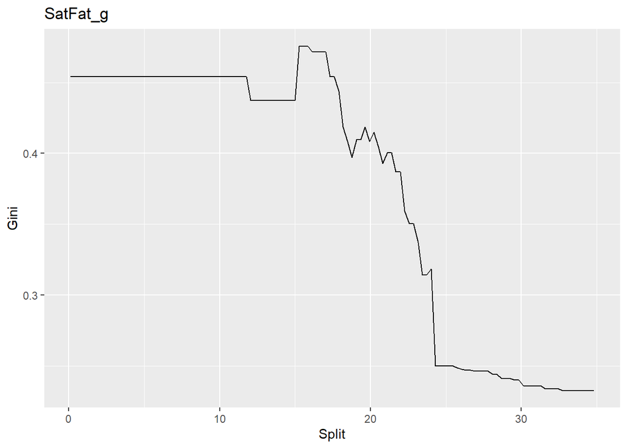

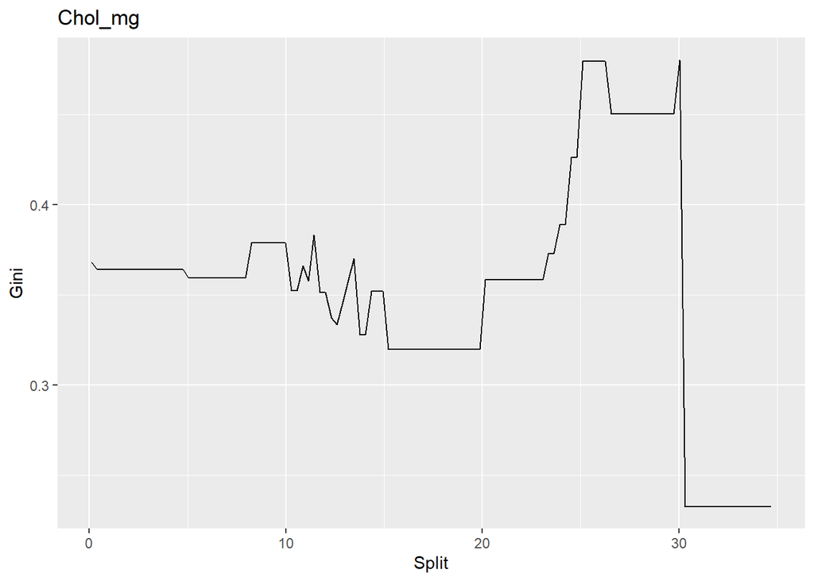

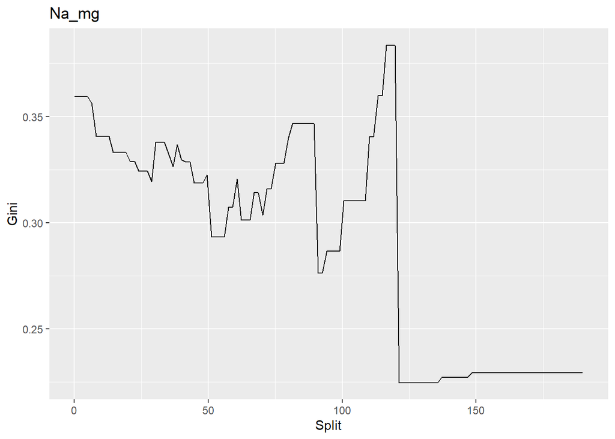

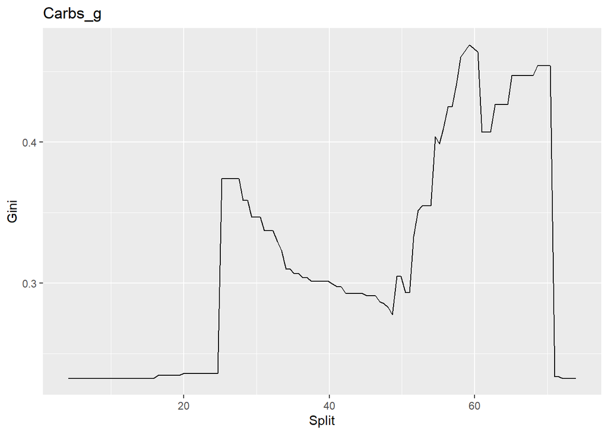

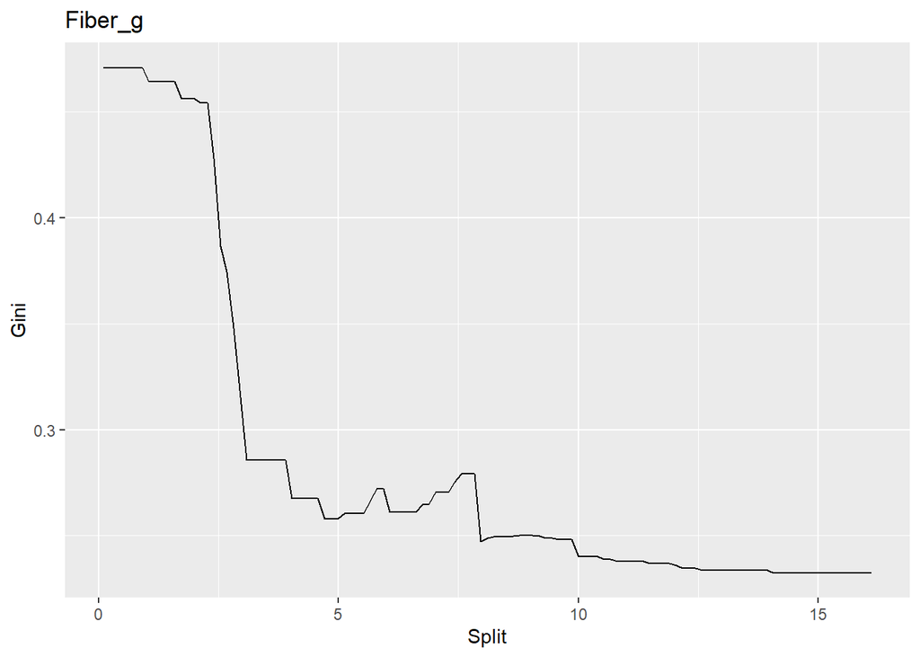

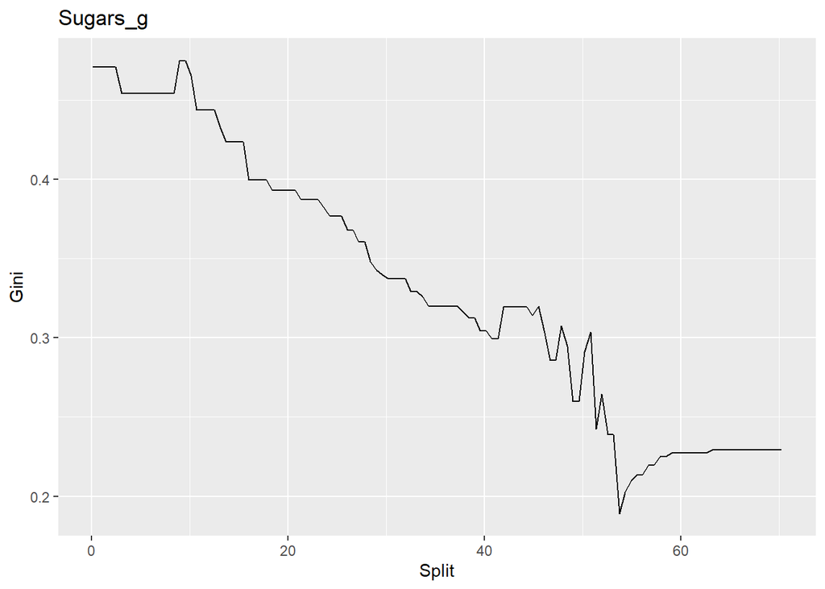

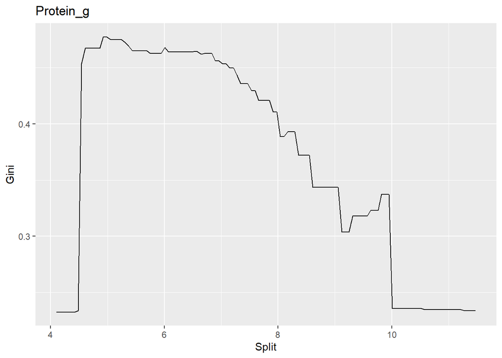

# Question 3

For each of the simulated data sets provided, using the tour, parallel coordinate plot, scatterplot matrix or any other technique you like, determine the main structure in the data: how many groups there are, whether there are any outliers, overall shape. Write a paragraph on what you find in the data and your approach.

# Dataset 1

```
## # A tibble: 5 x 2
##   cluster `n()`
##     <int> <int>
## 1       1    50
## 2       2    49
## 3       3    51
## 4       4    50
## 5       5    50
```

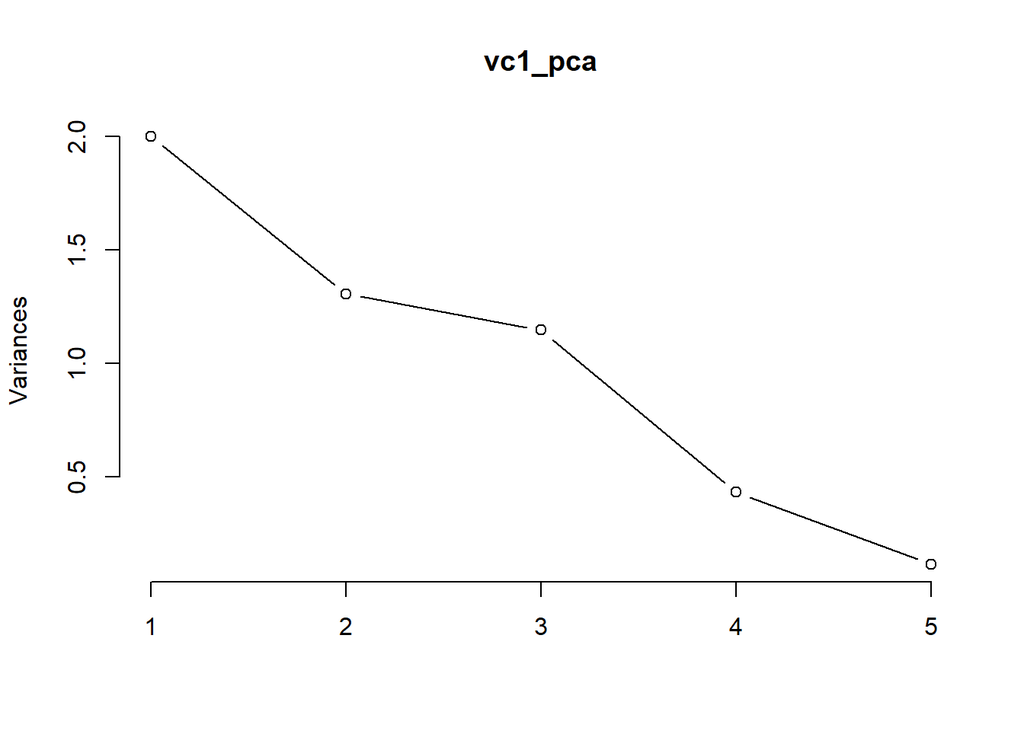

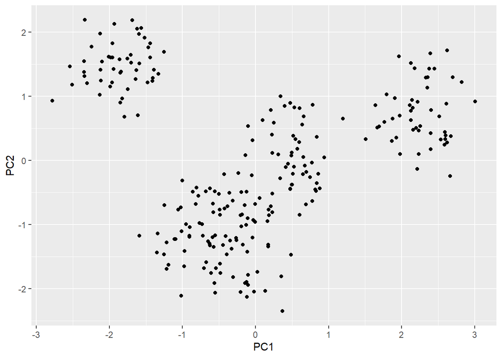

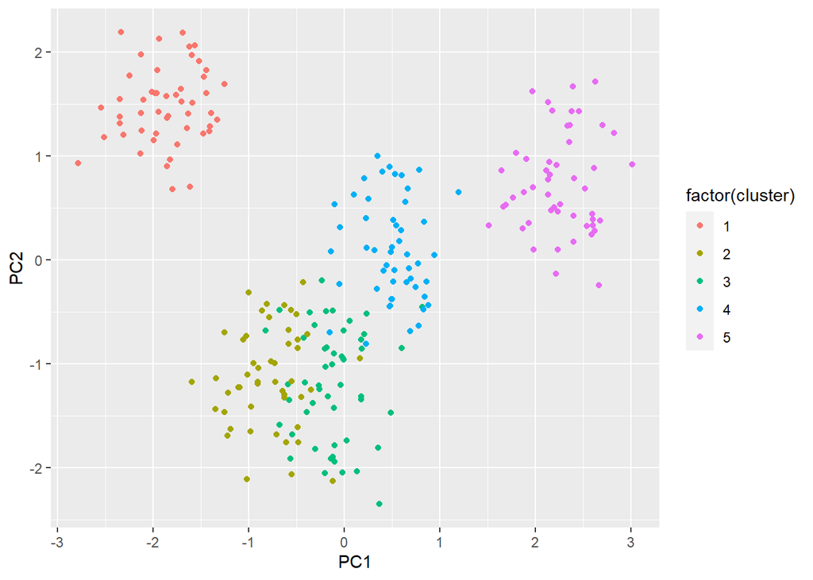

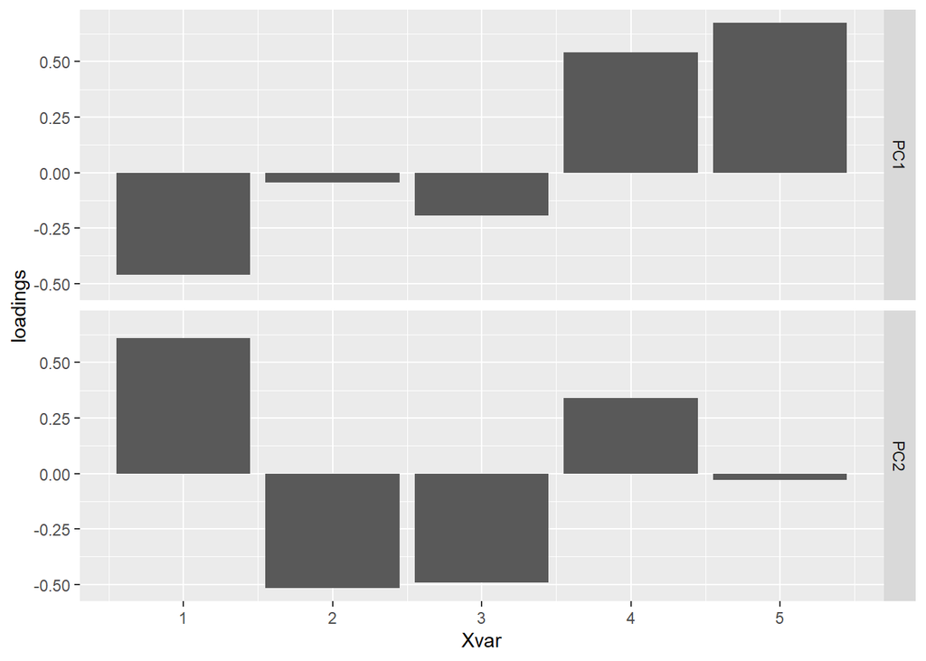

# Dataset 2

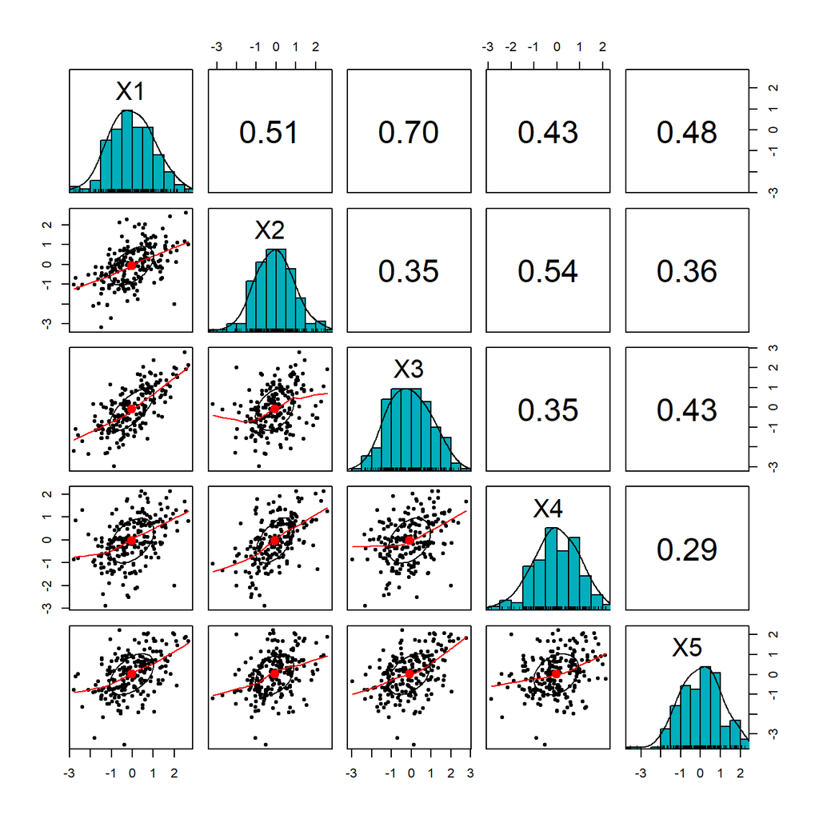

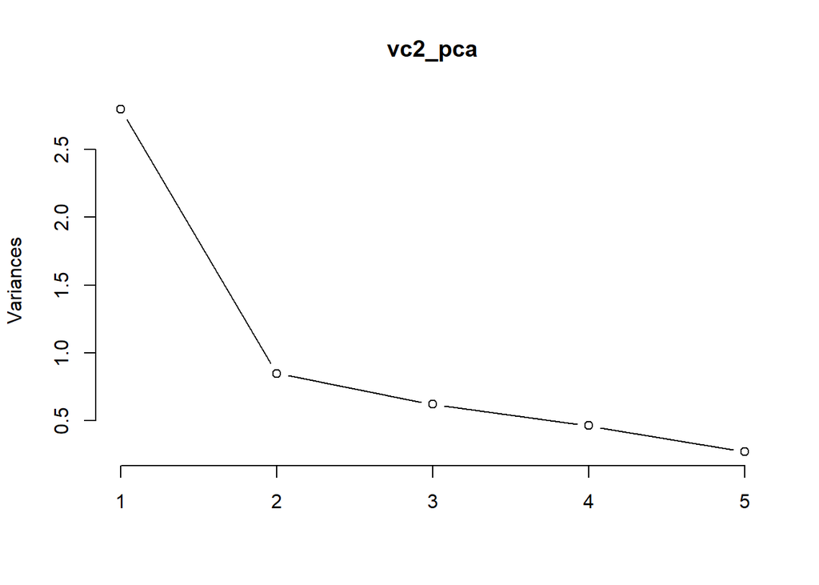

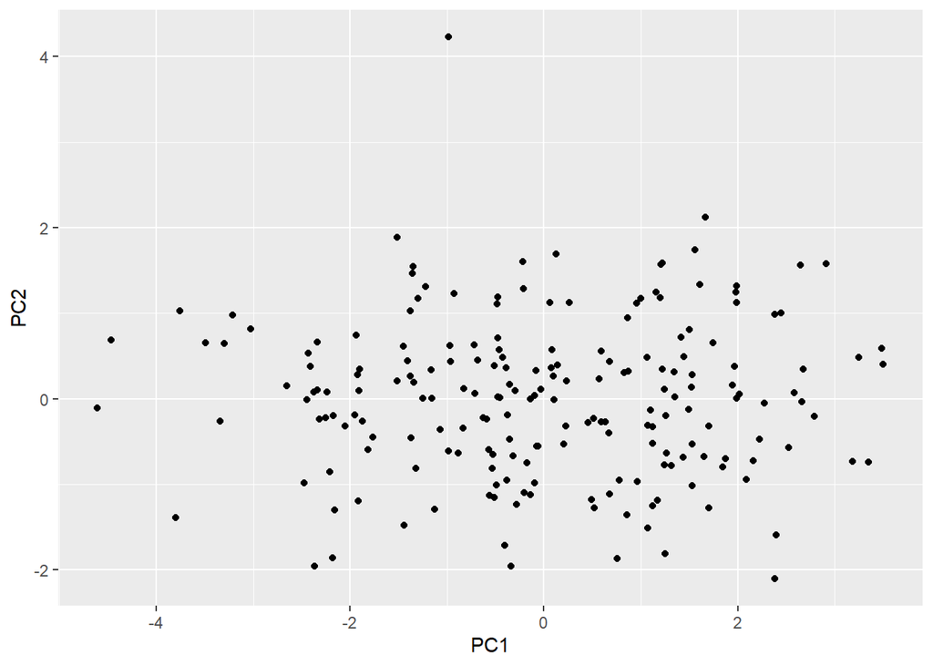

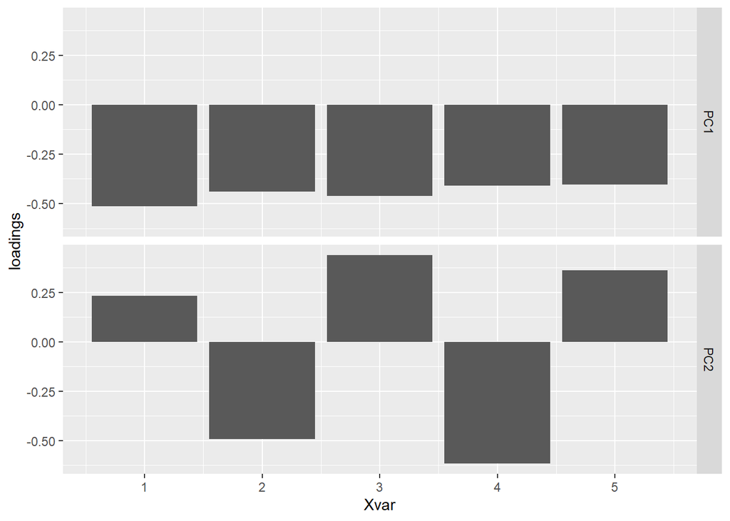

# Dataset 3

Dataset 3 appears to be mushroom shaped, with a dense stem and a sparse cap upon inspection by tour. Using a correlation matrix shows that X1 and X2 could be two normal distributions with the same mean but different variances overlaid on one another, and the variables X3, X4 and X5 all can be shown to be right skewed distributions with a certain degree of positive co variance, this results in the dense tight stem near the centre of the distributions, and the long tail fanning out into the cap of the mushroom.

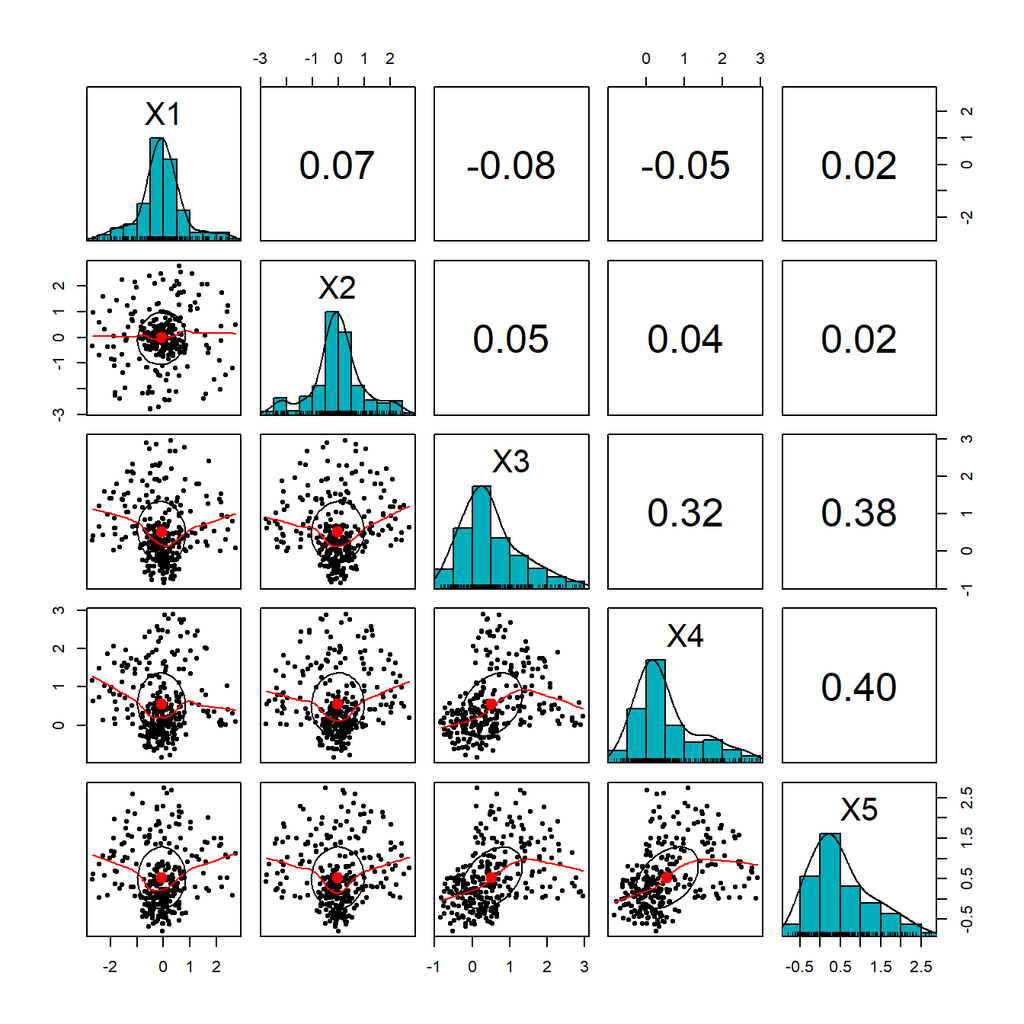

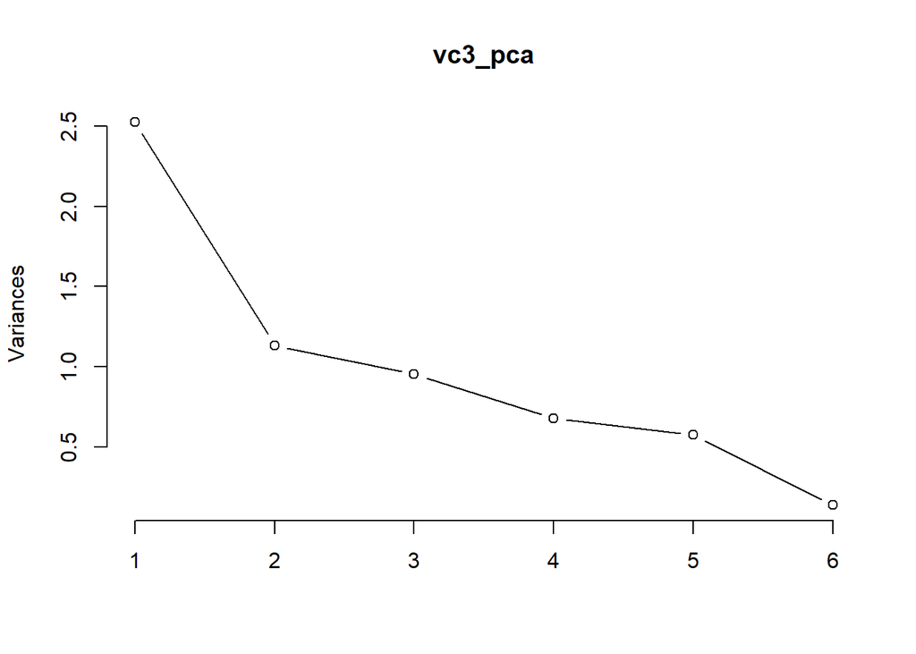

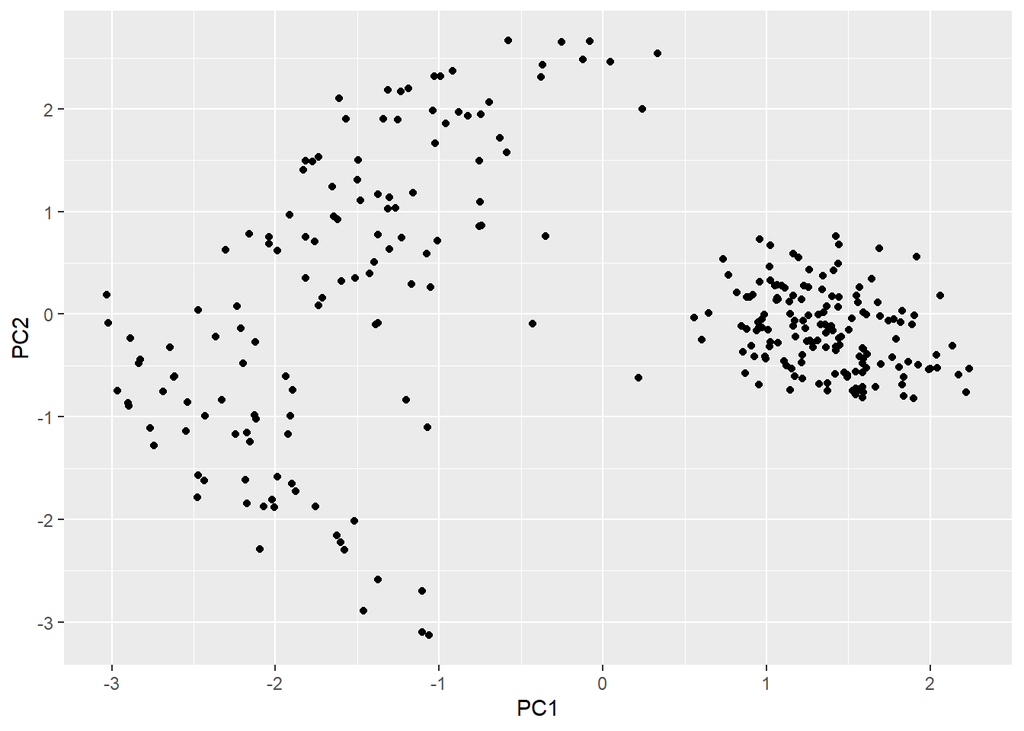

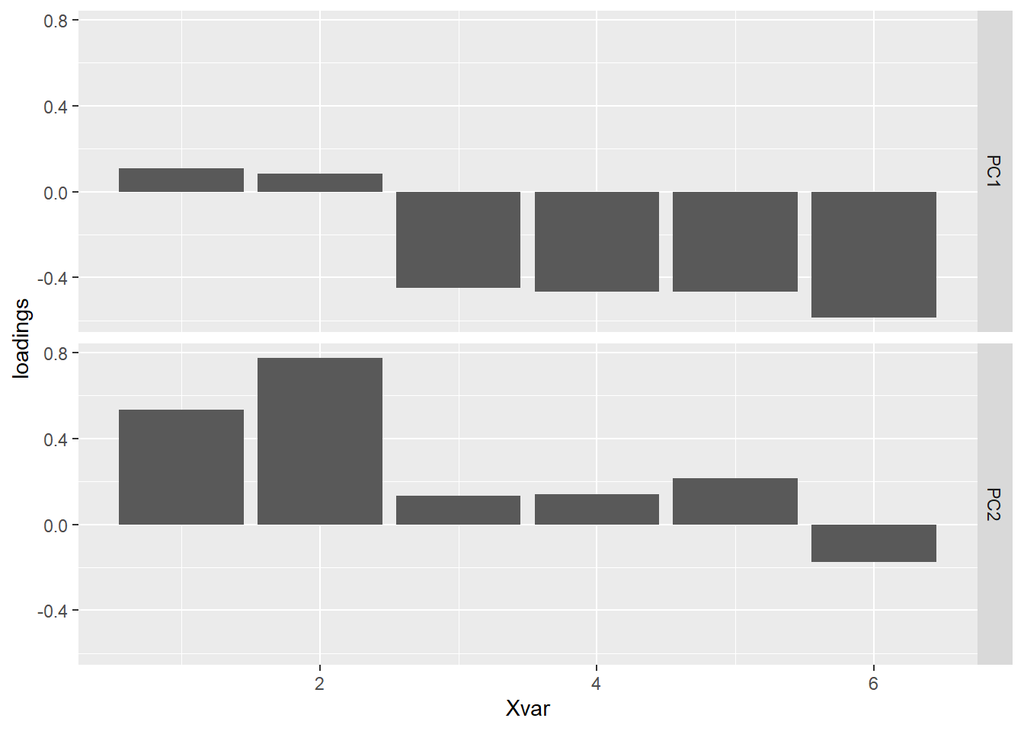

# Dataset 4

The data appears to have complex features when inspecting with the tour. Using a scatterplot matrix we see that the data is clustered into groups along X4 and X5, with a range of variances but clearly delineated. This is seen in the cross-correlations between the two columns and the other three variables which appear to be all more or less zero centered gaussian distributions. When the grouped variables are projected onto the normally distributed variables, we see the characteristic cruciform shape, with the gaps along the X4 or X5 axis where the groups break.

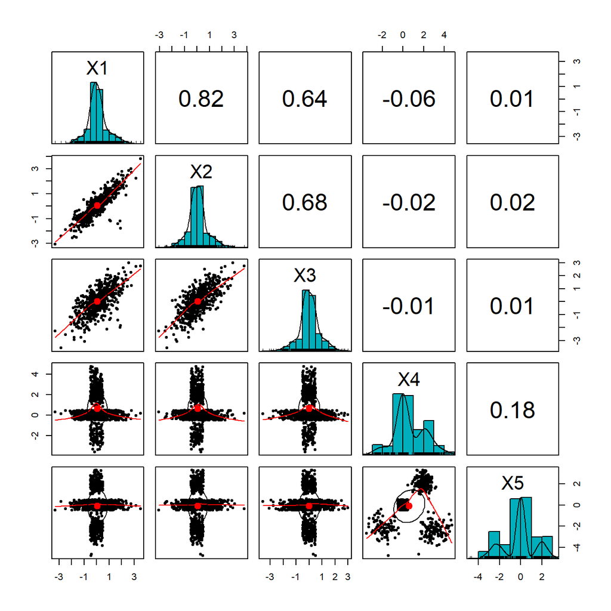

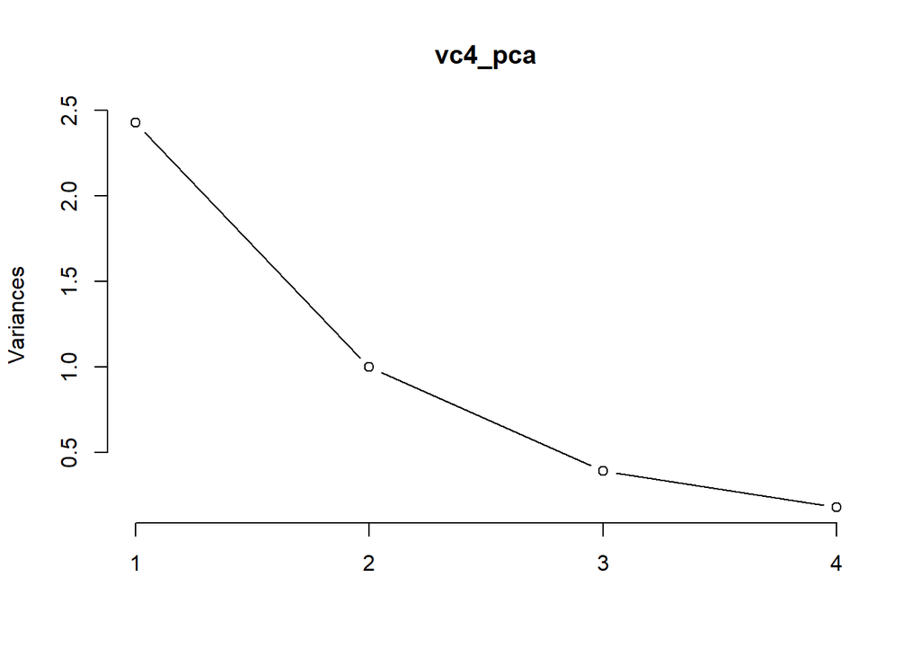

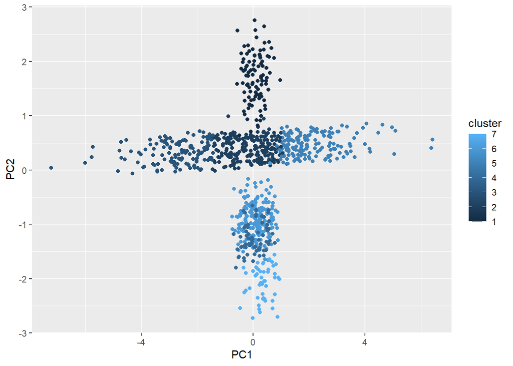

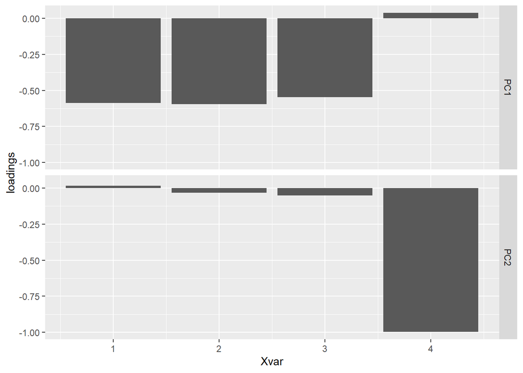

# Dataset 5

Using “Any technique”, found the following by googling column names to identify the original synthesized dataset [3]

Part A was generated: 5000 (I think) 5-variable, uncorrelated, i.i.d. Gaussian observations.

To get part B, I duplicated part A, then reversed the sign on the observations for 3 of the 5 variables.

Part B was appended to Part A.

The order of the observations was randomized.

While waiting for my tardy car-pool companion, I took a piece of graph paper, and figured out a dot-matrix representation of the word, “EUREKA.” I then added these observations to the “center” of the (sic) datatset.

The data were scaled, by variable (something like 1,3,5,7,11).

The data were rotated, then translated.

A few points in space within the datacloud were chosen as ellipsoid centers, then for each center, all observations within a (scaled and rotated) radius were identified, and eliminated - to form ellipsoidal voids.

The variables were given entirely ficticious names.

# In Text

[1]B. Myers, ‘Is Dark Chocolate Healthier Than Milk Chocolate?’, LIVESTRONG.COM. https://www.livestrong.com/article/355599-the-health-benefits-of-dark-vs-milk-chocolate/ (accessed May 05, 2020).

[2]G. James, D. Witten, T. Hastie, and R. Tibshirani, An Introduction to Statistical Learning: with Applications in R. New York: Springer-Verlag, 2013.

[3]R. K. Anderson, Visual Data Mining: The VisMiner Approach. John Wiley & Sons, 2012.

# Software used

Barret Schloerke, Jason Crowley, Di Cook, Francois Briatte, Moritz Marbach, Edwin Thoen, Amos Elberg and Joseph Larmarange (2020). GGally: Extension to ‘ggplot2’. R package version 1.5.0. https://CRAN.R-project.org/package=GGally

Ben Gorman (2018). mltools: Machine Learning Tools. R package version 0.3.5. https://CRAN.R-project.org/package=mltools

C. Sievert. Interactive Web-Based Data Visualization with R, plotly, and shiny. Chapman and Hall/CRC Florida, 2020.

Erich Neuwirth (2014). RColorBrewer: ColorBrewer Palettes. R package version 1.1-2. https://CRAN.R-project.org/package=RColorBrewer

Hadley Wickham, Dianne Cook, Heike Hofmann, Andreas Buja (2011). tourr: An R Package for Exploring Multivariate Data with Projections. Journal of Statistical Software, 40(2), 1-18. URL http://www.jstatsoft.org/v40/i02/.

Karthik Ram and Hadley Wickham (2018). wesanderson: A Wes Anderson Palette Generator. R package version 0.3.6. https://CRAN.R-project.org/package=wesanderson

Max Kuhn (2020). caret: Classification and Regression Training. R package version 6.0-86. https://CRAN.R-project.org/package=caret

R Core Team (2020). R: A language and environment for statistical computing. R Foundation for Statistical Computing, Vienna, Austria. URL https://www.R-project.org/.

Revelle, W. (2019) psych: Procedures for Personality and Psychological Research, Northwestern University, Evanston, Illinois, USA, https://CRAN.R-project.org/package=psych Version = 1.9.12.

Venables, W. N. & Ripley, B. D. (2002) Modern Applied Statistics with S. Fourth Edition. Springer, New York. ISBN 0-387-95457-0 Terry Therneau and Beth Atkinson (2019). rpart: Recursive Partitioning and Regression Trees. R package version 4.1-15. https://CRAN.R-project.org/package=rpart

Wickham et al., (2019). Welcome to the tidyverse. Journal of Open Source Software, 4(43), 1686, https://doi.org/10.21105/joss.01686